[figure not shown]

# Simulación de modelos mixtos

Freddy Hernández

2019-febrero-02

## Introducción

En esta publicación se mostrará al lector cómo simular datos de modelos lineales y la forma de estimar los parámetros. Los modelos a simular son:

1. Modelo lineal clásico,
2. Modelo lineal con intercepto aleatorio,
3. Modelo lineal con pendiente aleatoria,
4. Modelo lineal con intercepto y pendiente aleatoria.

## Ilustración de un modelo mixto

Se recomienda al lector que visite el enlace mostrado abajo para que vea una ilustración muy interesante de modelos mixtos. Los parámetros usados en las simulaciones fueron inspirados en la ilustración.

http://mfviz.com/hierarchical-models/

## Simulando datos de modelo lineal clásico

Suponga que queremos simular $n=50$ observaciones del siguiente modelo con vector de parámetros $\boldsymbol{\Theta}=(\beta_0=59, \beta_1=1, \sigma=1)^\top$.

$$\begin{align*}
y_i &\sim \mathcal{N}(\mu_i, \sigma^2) \\
\mu_i &= 59 + 1 \, x_i \\
\sigma &= 1 \\
x &\sim Uniforme[1, 9]
\end{align*}$$

Con el siguiente código se simula el conjunto de datos de interés.

```r
n <- 50
x <- sample(1:9, size=n, replace=TRUE) # Uniforme discreta [1, 9]
sig <- 1
media <- 59 + 1 * x
y <- rnorm(n=n, mean=media, sd=sig)
```

Vamos a construir un diagrama de dispersión para los datos simulados.

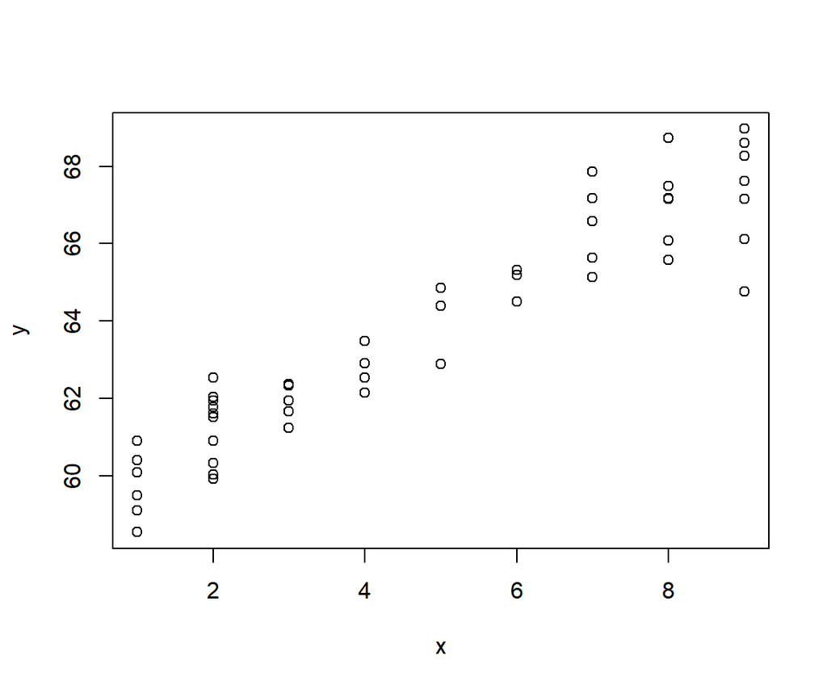

```r
plot(y ~ x)
```

Ajustemos un modelo para recuperar el vector de parámetros parámetros $\boldsymbol{\Theta}$.

```r
mod1 <- lm(y ~ x)
c(mod1$coef, sigma=summary(mod1)$sigma)
```

```
## (Intercept)           x       sigma
##  59.1366969   0.9651877   0.9670255
```

De la salida anterior vemos que vector de parámetros estimado está cerca de $\boldsymbol{\Theta}=(\beta_0=59, \beta_1=1, \sigma=1)^\top$.

Vamos a agregar la línea del modelo ajustado.

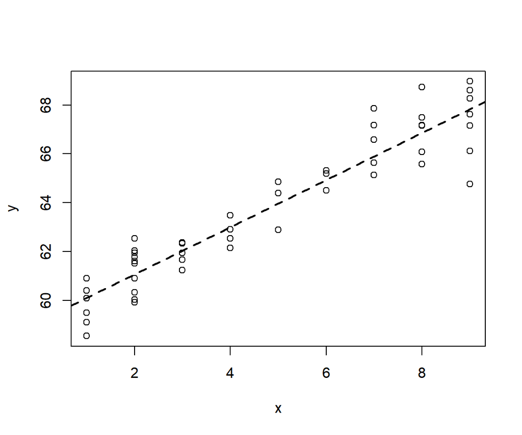

```r
plot(y ~ x)
abline(mod1, lty='dashed', lwd=2)
```

## Simulando datos con intercepto aleatorio

Suponga que ahora queremos simular $n_i=10$ observaciones para $n_g=5$ grupos (en total 50) usando el siguiente modelo mixto con intercepto aleatorio con vector de parámetros $\boldsymbol{\Theta}=(\beta_0=59, \beta_1=1, \sigma=1, \sigma_{b0}=10)^\top$.

$$\begin{align*}
y_{ij} &\sim \mathcal{N}(\mu_{ij}, \sigma^2) \\
\mu_{ij} &= 59 + 1 \, x_{ij} + b_{0i} \\
\sigma &= 1 \\
b_0 &\sim \mathcal{N}(0, \sigma_{b0}^2) \\
x &\sim Uniforme[1, 9] \\
i &= 1, 2, \ldots, n_g \quad j=1, 2, \ldots, n_i
\end{align*}$$

```r
sig <- 1
sd_b0 <- 10

ng <- 5        # número de grupos
ni <- 10       # número de obs por grupo
n <- ng * ni   # número de obs total

grupo <- rep(1:5, each=ni) # Variable de agrupación

x <- sample(1:9, size=n, replace=TRUE)
b0 <- rnorm(n=ng, mean=0, sd=sd_b0)  # Vector con los cinco b0
b0_rep <- rep(b0, each=ni)           # Vector con los b0 repetidos
media <- 59 + 1 * x + b0_rep
y <- rnorm(n=n, mean=media, sd=sig)

dt <- data.frame(grupo=grupo, x=x, b0_rep, y=y)
```

Exploremos lo que hay dentro de `dt`.

```r
dt[1:15, ]
```

```
##    grupo x    b0_rep        y
## 1      1 1  2.204804 61.77965
## 2      1 2  2.204804 64.19926
## 3      1 5  2.204804 66.05037
## 4      1 3  2.204804 65.19055
## 5      1 5  2.204804 65.75986
## 6      1 6  2.204804 66.08102
## 7      1 4  2.204804 64.99159
## 8      1 8  2.204804 70.17006
## 9      1 8  2.204804 68.25086
## 10     1 3  2.204804 65.11669
## 11     2 1 -1.703637 58.95638
## 12     2 3 -1.703637 60.27749
## 13     2 6 -1.703637 65.36535
## 14     2 1 -1.703637 59.03636
## 15     2 7 -1.703637 65.22484
```

Vamos a construir un diagrama de dispersión para los datos simulados.

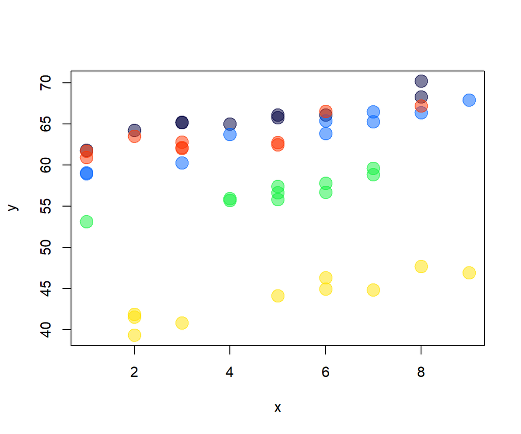

```r
colores <- c("#00004080", "#0063FF80", "#13F24080", "#FFE20180", "#FF330080")
with(dt, plot(y ~ x, pch=20, col=colores[dt$grupo], cex=3))
```

Ajustemos un modelo para recuperar el vector de parámetros parámetros $\boldsymbol{\Theta}$, para esto usemos la función `lme` del paquete `nlme`.

```r
library(nlme)
mod2 <- lme(y ~ x, random = ~ 1 | grupo, data=dt)
summary(mod2)
```

```
## Linear mixed-effects model fit by REML
##  Data: dt
##        AIC      BIC   logLik
##   175.6936 183.1784 -83.8468
##
## Random effects:
##  Formula: ~1 | grupo
##         (Intercept)  Residual
## StdDev:    9.182026 0.9453794
##
## Fixed effects: y ~ x
##                Value Std.Error DF t-value p-value
## (Intercept) 54.15459  4.117718 44 13.1516       0
## x            0.95896  0.058832 44 16.2999       0
##  Correlation:
##   (Intr)
## x -0.067
##
## Standardized Within-Group Residuals:
##          Min           Q1          Med           Q3          Max
## -2.090488661 -0.681258466  0.001947846  0.883247659  2.068938211
##
## Number of Observations: 50
## Number of Groups: 5
```

De la tabla anterior vemos que el vector de parámetros estimado $\hat{\boldsymbol{\Theta}}$ no está tan alejado de $\boldsymbol{\Theta}$.

Los efectos fijos estimados $\beta_0$ y $\beta_1$ se obtienen así:

```r
fixef(mod2)
```

```
## (Intercept)           x
##  54.1545869   0.9589589
```

Vamos a recuperar las predicciones de los 5 interceptos aleatorios (efectos aleatorios) y a compararlas con los verdaderos $b_{0}$.

```r
cbind(ranef(mod2), b0)
```

```
##   (Intercept)          b0
## 1    7.281371   2.2048045
## 2    4.558740  -1.7036372
## 3   -2.200976  -7.2366656
## 4  -15.109732 -19.6426321
## 5    5.470597   0.2417036
```

De la tabla anterior vemos que los $\tilde{b_{0}}$ son cercanos a los verdaderos $b_{0}$ simulados.

Usando los efectos fijos y los efectos aleatorios podemos obtener las expresiones ($\hat{\beta}_0 + \hat{\beta}_1 x_{ij} + b_{0i}$) para los modelos de cada grupo así:

```r
coef(mod2)
```

```
##   (Intercept)         x
## 1    61.43596 0.9589589
## 2    58.71333 0.9589589
## 3    51.95361 0.9589589
## 4    39.04485 0.9589589
## 5    59.62518 0.9589589
```

Usando la información anterior se puede dibujar el modelo ajustado para cada grupo.

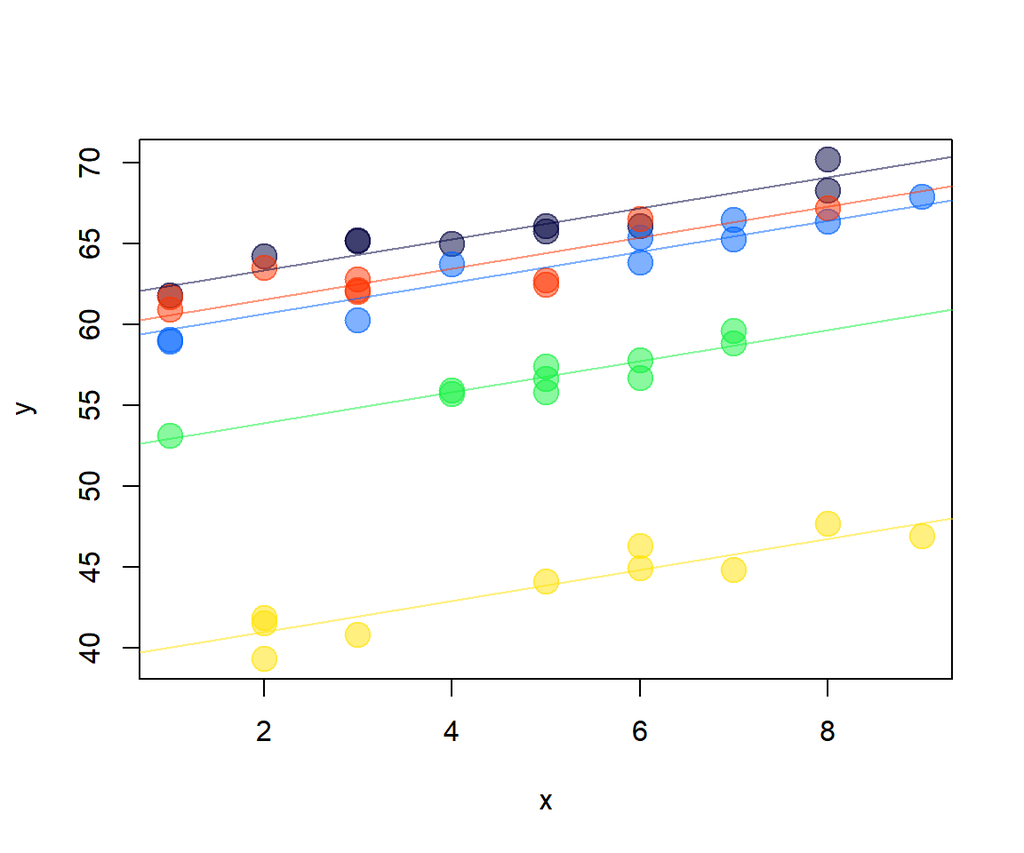

```r
coef <- coef(mod2)
with(dt, plot(y ~ x, pch=20, col=colores[dt$grupo], cex=3))
for (i in 1:5) abline(a=coef[i, 1], b=coef[i, 2], col=colores[i])
```

## Simulando datos con pendiente aleatoria

$$\begin{align*}
y_{ij} &\sim \mathcal{N}(\mu_{ij}, \sigma^2) \\
\mu_{ij} &= 59 + 1 \, x_{ij} + b_{1i} \, x_{ij} \\
\sigma &= 1 \\
b_1 &\sim \mathcal{N}(0, \sigma_{b1}^2) \\
x &\sim Uniforme[1, 9] \\
i &= 1, 2, \ldots, n_g, \quad j=1, 2, \ldots, n_i
\end{align*}$$

```r
sig <- 1
sd_b1 <- 5

ng <- 5
ni <- 10
n <- ng * ni

grupo <- rep(1:5, each=ni)
n <- ng * ni
x <- sample(1:9, size=n, replace=TRUE)
b1 <- rnorm(n=ng, mean=0, sd=sd_b0)
b1_rep <- rep(b0, each=ni)
media <- 59 + 1 * x + b1_rep * x
y <- rnorm(n=n, mean=media, sd=sig)

dt <- data.frame(grupo=grupo, x=x, b1_rep, y=y)
```

Exploremos lo que hay dentro de `dt`.

```r
dt[1:15, ]
```

```
##    grupo x    b1_rep        y
## 1      1 9  2.204804 86.52366
## 2      1 4  2.204804 71.73799
## 3      1 8  2.204804 85.04519
## 4      1 1  2.204804 62.44768
## 5      1 6  2.204804 78.08039
## 6      1 2  2.204804 64.17893
## 7      1 3  2.204804 68.14157
## 8      1 7  2.204804 81.06780
## 9      1 5  2.204804 76.41245
## 10     1 1  2.204804 62.25764
## 11     2 8 -1.703637 54.55088
## 12     2 3 -1.703637 57.46429
## 13     2 5 -1.703637 55.67543
## 14     2 8 -1.703637 53.66833
## 15     2 7 -1.703637 52.80875
```

Vamos a construir un diagrama de dispersión para los datos simulados.

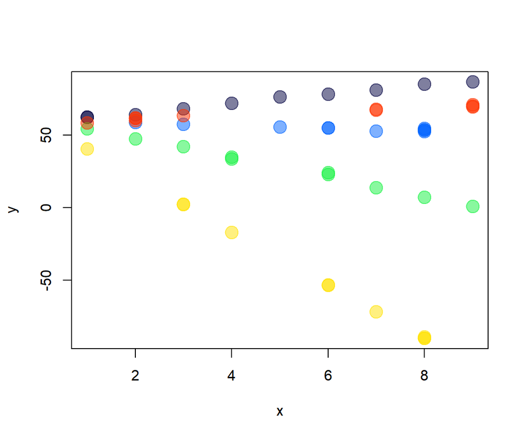

```r
with(dt, plot(y ~ x, pch=20, col=colores[dt$grupo], cex=3))
```

Ajustemos un modelo para recuperar el vector de parámetros parámetros $\boldsymbol{\Theta}$, para esto usemos la función `lme` del paquete `nlme`.

```r
mod3 <- lme(y ~ x, random = ~ -1 + x | grupo, data=dt)
summary(mod3)
```

```
## Linear mixed-effects model fit by REML
##  Data: dt
##        AIC      BIC    logLik
##   200.0718 207.5566 -96.03589
##
## Random effects:
##  Formula: ~-1 + x | grupo
##                x Residual
## StdDev: 8.797098 1.062857
##
## Fixed effects: y ~ x
##                Value Std.Error DF   t-value p-value
## (Intercept) 59.18676  0.334806 44 176.77912  0.0000
## x           -4.27832  3.934599 44  -1.08736  0.2828
##  Correlation:
##   (Intr)
## x -0.013
##
## Standardized Within-Group Residuals:
##         Min          Q1         Med          Q3         Max
## -2.02075950 -0.53202741  0.09063363  0.56063799  2.66588125
##
## Number of Observations: 50
## Number of Groups: 5
```

Los efectos fijos estimados $\beta_0$ y $\beta_1$ se obtienen así:

```r
fixef(mod3)
```

```
## (Intercept)           x
##   59.186757   -4.278317
```

Vamos a recuperar las predicciones de las 5 pendientes aleatorios (efectos aleatorios) y a compararlas con los verdaderos $b_{1}$.

```r
cbind(ranef(mod3), b1)
```

```
##            x         b1
## 1   7.421094  -2.558736
## 2   3.552754 -13.011897
## 3  -2.027517  -7.877748
## 4 -14.415963  -3.722522
## 5   5.469633   1.994824
```

Usando los efectos fijos y los efectos aleatorios podemos obtener las expresiones ($\hat{\beta}_0 + \hat{\beta}_1 x_{ij} + b_{1i} x_{ij}$) para los modelos de cada grupo así:

```r
coef(mod3)
```

```
##   (Intercept)           x
## 1    59.18676   3.1427772
## 2    59.18676  -0.7255632
## 3    59.18676  -6.3058342
## 4    59.18676 -18.6942803
## 5    59.18676   1.1913162
```

Usando la información anterior se puede dibujar el modelo ajustado para cada grupo.

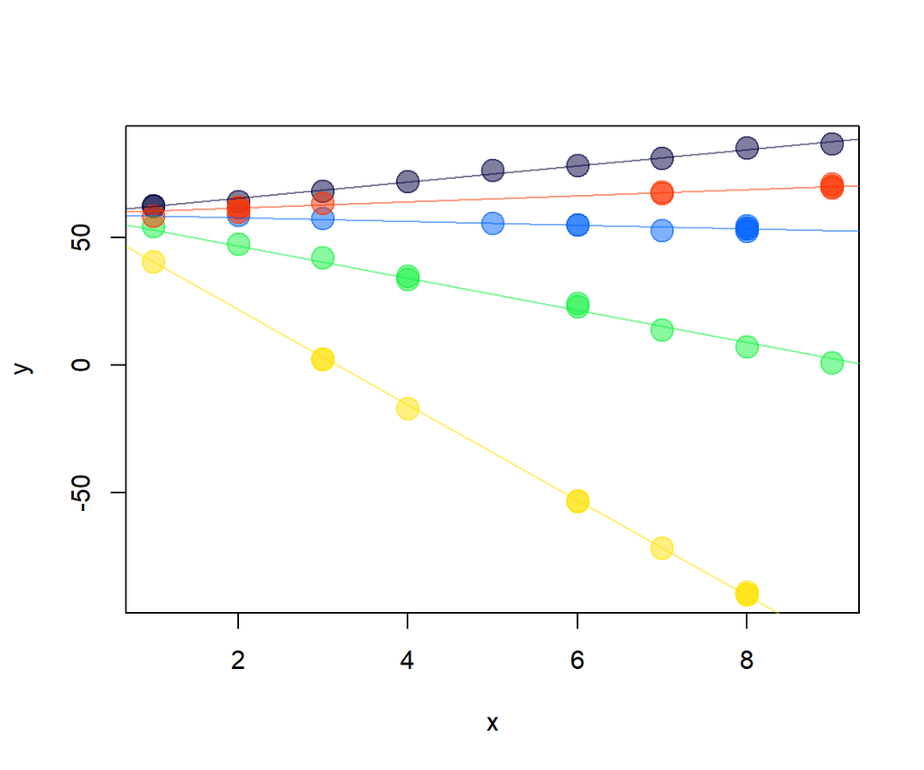

```r
coef <- coef(mod3)
with(dt, plot(y ~ x, pch=20, col=colores[dt$grupo], cex=3))
for (i in 1:5) abline(a=coef[i, 1], b=coef[i, 2], col=colores[i])
```

## Simulando datos con intercepto y pendiente aleatoria

Suponga que ahora queremos simular $n_i=10$ observaciones para $n_g=5$ grupos (en total 50) usando el siguiente modelo mixto con intercepto y pendiente aleatoria con vector de parámetros $\boldsymbol{\Theta}=(\beta_0=59, \beta_1=1, \sigma=1, \sigma_{b0}=9, \sigma_{b0}=4, \sigma_{b01}=-2)^\top$.

$$\begin{equation}
\begin{split}
y_{ij} &\sim \mathcal{N}(\mu_{ij}, \sigma^2), \\
\mu_{ij} &= 59 + 1 \, x_{ij} + b_{0i} + b_{1i} \, x_{ij} \\
\left (
\begin{matrix}
b_{0i} \\ b_{1i}
\end{matrix}
\right ) &\sim
\mathcal{N}\left ( \left ( \begin{matrix}
0 \\ 0
\end{matrix} \right ),
\left ( \begin{matrix}
\sigma^2_{b0} & \sigma_{b01} \\
\sigma_{b01} & \sigma^2_{b1}
\end{matrix} \right )
\right ) \\
x &\sim Uniforme[1, 9] \\
i &= 1, 2, \ldots, n_g \quad j=1, 2, \ldots, n_i
\end{split}
\end{equation}$$

```r
ng <- 5
ni <- 10
n <- ng * ni

sig <- 1

sd_b0 <- 9     # Matriz de covarianzas de los efectos aleatorios
sd_b1 <- 4
sd_b0b1 <- -2

library(MASS)
mu <- c(0, 0)
Sigma <- matrix(c(sd_b0^2, sd_b0b1, sd_b0b1, sd_b1^2), ncol=2)
b <- mvrnorm(n=ng, mu=mu, Sigma=Sigma)
b_rep <- b[rep(1:nrow(b), each=ni), ]

grupo <- rep(1:5, each=ni)
x <- sample(1:9, size=n, replace=TRUE)
media <- 59 + 1 * x + b_rep[, 1] + b_rep[, 2] * x
y <- rnorm(n=n, mean=media, sd=sig)

dt <- data.frame(grupo=grupo, x=x, b0=b_rep[, 1], b1=b_rep[, 2], y=y)
```

Exploremos lo que hay dentro de `dt`.

```r
dt[1:15, ]
```

```
##    grupo x         b0         b1         y
## 1      1 7  4.4442309  0.3004399 72.073452
## 2      1 5  4.4442309  0.3004399 70.493925
## 3      1 9  4.4442309  0.3004399 75.724734
## 4      1 9  4.4442309  0.3004399 75.276074
## 5      1 4  4.4442309  0.3004399 69.735776
## 6      1 4  4.4442309  0.3004399 67.500046
## 7      1 4  4.4442309  0.3004399 67.726195
## 8      1 3  4.4442309  0.3004399 67.618584
## 9      1 1  4.4442309  0.3004399 63.868624
## 10     1 9  4.4442309  0.3004399 77.255891
## 11     2 4 -0.8312049 -8.0236586 29.871973
## 12     2 6 -0.8312049 -8.0236586 14.388132
## 13     2 9 -0.8312049 -8.0236586 -4.568829
## 14     2 1 -0.8312049 -8.0236586 51.272741
## 15     2 5 -0.8312049 -8.0236586 22.653546
```

Vamos a construir un diagrama de dispersión para los datos simulados.

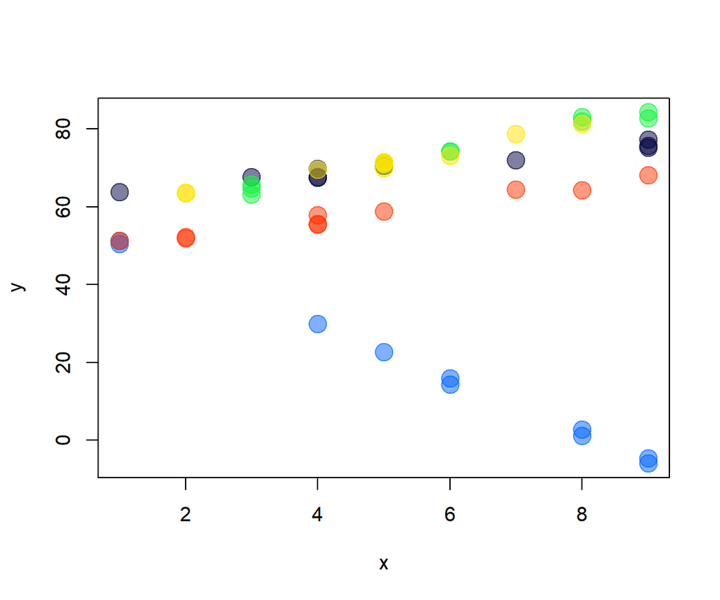

```r
with(dt, plot(y ~ x, pch=20, col=colores[dt$grupo], cex=3))
```

Ajustemos un modelo para recuperar el vector de parámetros parámetros $\boldsymbol{\Theta}$, para esto usemos la función `lme` del paquete `nlme`.

```r
mod4 <- lme(y ~ x, random = ~ 1 + x | grupo, data=dt)
summary(mod4)
```

```
## Linear mixed-effects model fit by REML
##  Data: dt
##        AIC      BIC    logLik
##   207.8849 219.1121 -97.94245
##
## Random effects:
##  Formula: ~1 + x | grupo
##  Structure: General positive-definite, Log-Cholesky parametrization
##             StdDev    Corr
## (Intercept) 5.2667186 (Intr)
## x           4.2931552 -0.229
## Residual    0.9975287
##
## Fixed effects: y ~ x
##                Value Std.Error DF  t-value p-value
## (Intercept) 56.04091  2.380925 44 23.53746  0.0000
## x            0.57045  1.920896 44  0.29697  0.7679
##  Correlation:
##   (Intr)
## x -0.231
##
## Standardized Within-Group Residuals:
##        Min         Q1        Med         Q3        Max
## -1.7425547 -0.6015407 -0.1043463  0.7253231  1.8748637
##
## Number of Observations: 50
## Number of Groups: 5
```

Al igual que en los ejemplos anteriores, se puede dibujar el modelo ajustado para cada grupo.

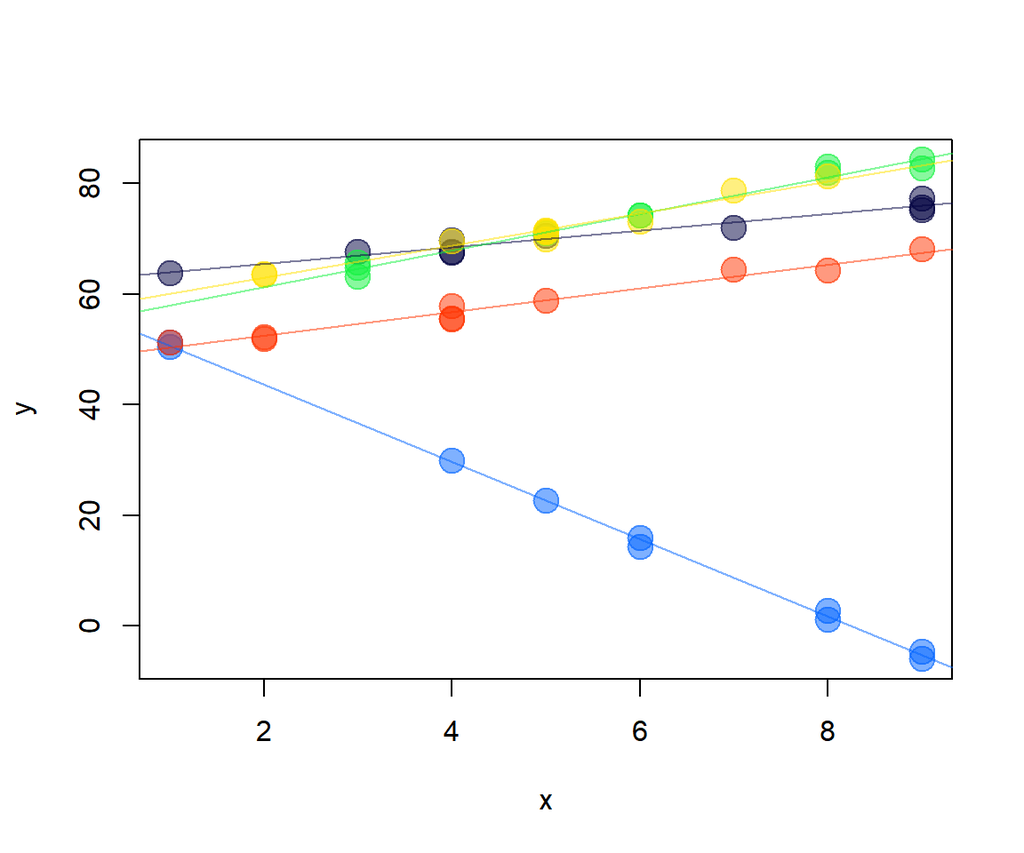

```r
coef <- coef(mod4)
with(dt, plot(y ~ x, pch=20, col=colores[dt$grupo], cex=3))
for (i in 1:5) abline(a=coef[i, 1], b=coef[i, 2], col=colores[i])
```

## Tarea

1. ¿Es posible que en un modelo mixto $y$ se distribuya no normal?
2. Consultar en la web ejemplos sencillos (con una sola covariable $x$) de modelos mixtos en los cuales la variable respuesta siga una distribución Poisson, binomial y gamma.
3. Para cada uno de los ejemplos encontrados, simular datos usando la estructura del ejemplo y luego estimar los parámetros.

Fin